# deSolve to denim

```r
library(denim)
library(deSolve)
```

## Migrate deSolve code to denim

### Original code in deSolve

The model used for demonstrating the process of migrating code from `deSolve` to `denim` is as followed

```r
# --- Model definition in deSolve
transition_func <- function(t, state, param){
  with(as.list( c(state, param) ), {
      dS = -beta*S*I/N
      dI1 = beta*S*I/N - rate*I1
      dI2 = rate*I1 - rate*I2
      dI =  dI1 + dI2
      dR = rate*I2
      list(c(dS, dI, dI1, dI2, dR))
  })
}

# ---- Model configuration
parameters <- c(beta = 0.3, rate = 1/3, N = 1000)
initialValues <- c(S = 999, I = 1, I1 = 1, I2=0, R=0)

# ---- Run simulation
times <- seq(0, 100) # simulation duration
ode_mod <- ode(y = initialValues, times = times, parms = parameters, func = transition_func)

# --- show output
ode_mod <- as.data.frame(ode_mod)
head(ode_mod[-1, c("time", "S", "I", "R")])
```

```
##   time        S        I          R
## 2    1 998.6561 1.294182 0.04969647
## 3    2 998.2239 1.594547 0.18152864
## 4    3 997.6985 1.921416 0.38010527
## 5    4 997.0695 2.290735 0.63971843
## 6    5 996.3225 2.716551 0.96093694
## 7    6 995.4387 3.212577 1.34869352
```

### Model definition

Similar to `deSolve`, transitions between compartments in `denim` can be defined using ordinary differential equations (ODEs). However, `denim` extends it by providing the option to directly express the dwell time distribution.

To utilize this option from `denim`, the user must first identify which transitions can best describe the ones in their `deSolve` model.

**Identify distribution**

```r
# --- Model definition in deSolve
transition_func <- function(t, state, param){
  with(as.list( c(state, param) ), {

      # For S -> I transition, since it involves parameters (beta, N),
      # the best transition to describe this is using a mathematical formula
      dS = -beta*S*I/N

      # For I -> R transition, linear chain trick is applied --> implies Erlang distributed dwell time
      # Hence, we can use d_gamma from denim
      dI1 = beta*S*I/N - rate*I1
      dI2 = rate*I1 - rate*I2
      dI =  dI1 + dI2
      dR = rate*I2
      list(c(dS, dI, dI1, dI2, dR))
  })
}
```

With the transitions identified, the user can then define the model in `denim`.

When using `denim` DSL, the model structure is given as a set of *key*-*value* pairs where

- *key* shows the transition direction between compartments in the format of `compartment -> out_compartment`.
- *value* is either a built-in distribution function that describe the transition or a mathematical expression.

```r
# --- Model definition in denim
transitions <- denim_dsl({
  S -> I = beta * S * I/N
  # shape is 2 from number of I sub compartments
  I -> R = d_gamma(rate = 1/3, shape = 2)
})
```

### Model configurations

Similar to `deSolve`, `denim` also ask the users to provide the initial values and any additional parameters in the form of named vectors or named list.

For the example `deSolve` code, while the users can use the `initalValues` from the `deSolve` code as is (`denim` will ignore unused `I1`, `I2` compartments as these sub-compartments will be automatically computed internally), it is recommended to remove redundant compartments (in this example, `I1` and `I2`).

For parameters, since `rate` is already defined in the distribution functions, the users only need to keep `beta` and `N` from the initial parameters vector. We do not need to specify the value for `timeStep` variable as this is a special variable in denim and will be defined later on.

```r
# remove I1, I2 compartments
denim_initialValues <- c(S = 999, I = 1, R=0)
denim_parameters <- c(beta = 0.3, N = 1000)
```

*Initialization of sub-compartments*: when there are multiple sub-compartments (e.g., compartment `I` consist of `I1` and `I2` sub-compartments), the initial population is always assigned to the first sub-compartment. In our example, since `I = 1`, denim will assign `I1 = 1` and `I2 = 0`.

There is also an option to distribute initial value across sub-compartments based on the specified distribution. To do this, simply set `dist_init` parameter of distribution function to `TRUE`.

```r
transitions <- denim_dsl({
  S -> I = beta * S * I/N
  I -> R = d_gamma(rate = 1/3, shape = 2, dist_init = TRUE)
})
```

However, for comparison purposes, we will keep this option `FALSE` for the remaining of this demonstration.

### Simulation

Lastly, the users need to define the simulation duration and time step for `denim` to run. Unlike `deSolve` which takes a time sequence, `denim` only require the simulation duration and time step.

Since `denim` uses a discrete time approach, time step must be set to a small value for the result to closely follow that of `deSolve` (in this example, 0.01).

```r
mod <- sim(transitions = transitions,
             initialValues = denim_initialValues,
             parameters = denim_parameters,
             simulationDuration = 100,
             timeStep = 0.01)

head(mod[mod$Time %% 1 == 0, ])
```

```
##     Time        S        I          R
## 1      0 999.0000 1.000000 0.00000000
## 101    1 998.6566 1.293759 0.04961535
## 201    2 998.2251 1.593725 0.18121212
## 301    3 997.7004 1.920189 0.37940195
## 401    4 997.0725 2.289061 0.63848007
## 501    5 996.3266 2.714365 0.95900520
```

## Compare output

The following plots show output from `denim` and `deSolve`

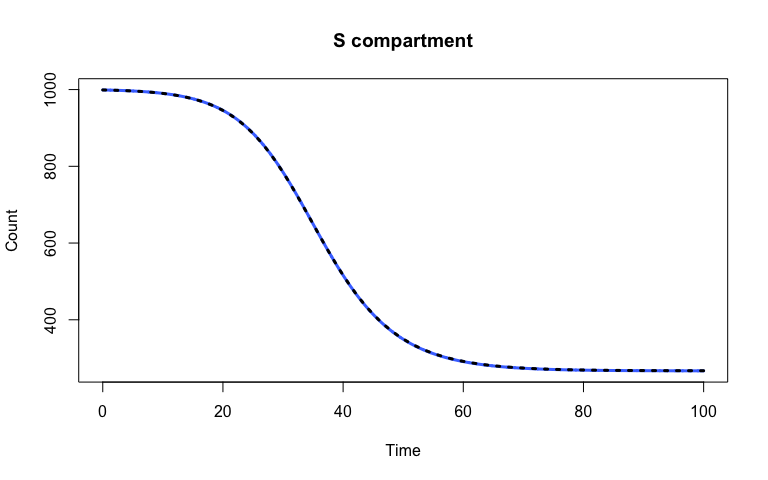

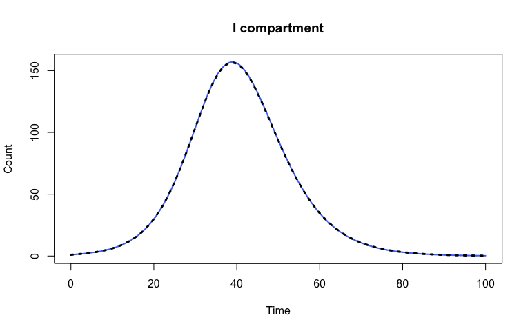

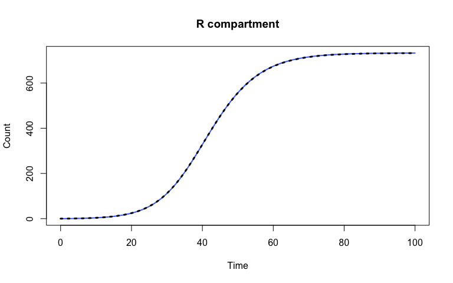